# Data Summaries

This is **Tutorial 3.4** from the ESL course taught at the Faculty of Informatics and Information Technologies, Slovak University of Technology in Bratislava.

The course loosely follows the book *An* *Introduction to Statistical Learning with Applications in R*[^1], while also drawing inspiration from Hadley Wickham’s *Advanced R*[^2]. You may notice small insights borrowed from these two excellent books here and there because they set a remarkably high standard for beginners, and they’re very hard to surpass.

| Version | Last Edit | Changes |
| --- | --- | --- |
| 2026.1 | 15-2-2026 | Minor text edits. |

This tutorial builds directly on the pre‑study material you’re expected to master by the end of week 2 and forms the foundation for the project you’ll tackle later. Study it carefully and complete all practice activities throughout weeks 3–6 to ensure you’re fully prepared.

### Motivation

Summarizing data is a fundamental aspect of data analysis in R, providing a concise overview of key statistics and insights from your dataset. Using functions from the tidyverse package, such as `summarise()` , `mutate()` and `count()`, you can efficiently compute summary statistics like means, medians, counts, and more.

The `summarise()` function is particularly useful for reducing data to a single summary statistic per group, often in conjunction with `group_by()`, allowing you to compute summaries for different categories within your data. Additionally, the `count()` function offers a straightforward way to count occurrences of unique values in one or more columns, integrating seamlessly into a tidyverse workflow. These tools, along with helper functions like `n()` and the flexibility of `across()`, make R a powerful language for data summarization.

### Similarities and Differences

`summarise()` and `mutate()` are two fundamental functions that handle data manipulation tasks. While they may seem similar, they serve complementary roles in data analysis. The `summarise()` function is typically used to reduce data down to a single summary statistic per group, often in conjunction with `group_by()`. This is particularly useful when you want to compute summaries like averages or counts for different categories within your data.

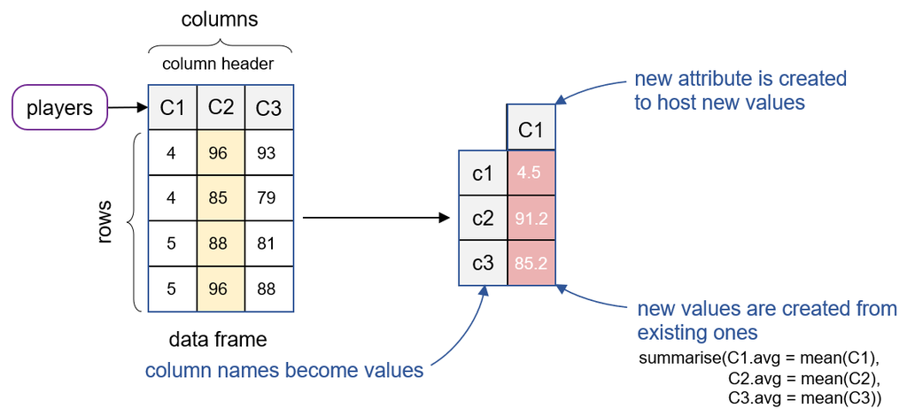

On the other hand, `mutate()` is used to add new variables or modify existing ones, usually without reducing the number of rows in the dataset. It’s handy for creating calculated fields or transforming data, exemplified as below.

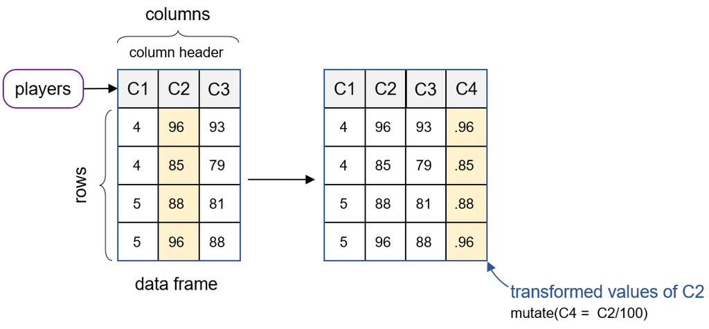

When used together, these functions can perform complex data transformations and analyses, allowing for a more streamlined and efficient workflow in R. For instance, one might use `mutate()` to create a new variable that is a function of existing variables, and then apply `summarise()` to compute a summary statistic of that new variable across different groups. This interplay between `summarise()` and `mutate()` is what makes them a powerful duo in data manipulation within R.

### The `summarise()` Function

```r
data %>%
  select(short_name, dob, skill_dribbling, league_level) %>%
  summarise(mean_dribbling = mean(skill_dribbling),
            min_dribbling = min(skill_dribbling),
            max_dribbling = max(skill_dribbling),
            number_of_records = n())
```

```
## # A tibble: 1 × 4
##   mean_dribbling min_dribbling max_dribbling number_of_records
##            <dbl>         <dbl>         <dbl>             <int>
## 1           55.7             4            96             19239
```

**Task 1:** Think conceptually how would you extend your code to summarize these four statistics for all `skill_` columns. Can it be done without repeating the same code four times? Can you extended your solution to any number of summary statistics (and any number to attributes)?

**Task 2:** Check the type and structure of the object that `summarise()` gives you. Does it have any interesting attributes and can these attributes be changed?

### Summarizing Data within Groups

The `group_by()` function computes summary statistics on subsets of data. For instance, one can slice your data by league level and then calculate summary statistics for each group separately.

```r
data %>%
  select(short_name, dob, league_level, skill_dribbling) %>%
  group_by(league_level) %>%
  summarise(mean_dribbling = mean(skill_dribbling),
            min_dribbling = min(skill_dribbling),
            max_dribbling = max(skill_dribbling),
            number_of_records = n())
```

```
## # A tibble: 6 × 5
##   league_level mean_dribbling min_dribbling max_dribbling number_of_records
##          <dbl>          <dbl>         <dbl>         <dbl>             <int>
## 1            1           56.0             4            96             14857
## 2            2           56.1             5            85              2513
## 3            3           52.8             4            75              1168
## 4            4           51.5             5            71               613
## 5            5           48.9             5            65                27
## 6           NA           55.4             7            78                61
```

R simplifies data summarization with its intuitive syntax that is shown above. After splitting the original data with `group_by()`, you can calculate various descriptive statistics for each group. Internally, `group_by()` uses `nest()` to create nested tibbles, or tables within tables. Functions defined within `summarise()` are applied to each nested table, and the resulting calculations are aggregated into one summary table printed to the console.

**Task 3:** `n()` is a prime example of a helper function for the `summarise()` function. Can you come up with other functions used to describe data distributions that could be used with `summarise()`?

**Task 4:** We have used only named functions within `summarise()` so far. However, this is often not what you want. Define your own anonymous function and use it within the `summarise()` code example from above.

### Counting Occurrences

Similar to `n()`, the `count()` function is designed for counting the occurrences of each unique combination of values in one or more columns and returns the result as a tibble.[^3]

```r
data %>% count(preferred_foot)
```

```
## # A tibble: 2 × 2
##   preferred_foot     n
##   <chr>          <int>
## 1 Left            4565
## 2 Right          14674
```

### Transforming Multiple Columns

The `across()`[^4] function in the tidyverse package allows you to apply the same transformation to a **range of columns** within a data frame. For example, you can calculate the mean of several numeric columns, which names or characteristics are provided.

```r
data %>%
  select(short_name, dob, league_level, starts_with("skill")) %>%
  group_by(league_level) %>%
  summarise(across(c(skill_dribbling, skill_curve), mean, na.rm = TRUE))
```

```
## # A tibble: 6 × 3
##   league_level skill_dribbling skill_curve
##          <dbl>           <dbl>       <dbl>
## 1            1            56.0        47.7
## 2            2            56.1        47.1
## 3            3            52.8        43.8
## 4            4            51.5        43.5
## 5            5            48.9        42.8
## 6           NA            55.4        49
```

You can use `across()` inside `summarise()` as in the case above, or define the function call using an anonymous function.

```r
data %>%
  select(short_name, dob, league_level, starts_with("skill")) %>%
  group_by(league_level) %>%
  summarise(across(where(is.numeric), ~ mean(., na.rm=TRUE)))
```

```
## # A tibble: 6 × 7
##   league_level skill_moves skill_dribbling skill_curve skill_fk_accuracy
##          <dbl>       <dbl>           <dbl>       <dbl>             <dbl>
## 1            1        2.37            56.0        47.7              42.7
## 2            2        2.34            56.1        47.1              41.9
## 3            3        2.22            52.8        43.8              39.1
## 4            4        2.17            51.5        43.5              39.4
## 5            5        2.22            48.9        42.8              39.4
## 6           NA        2.41            55.4        49                46
## # ℹ 2 more variables: skill_long_passing <dbl>, skill_ball_control <dbl>
```

The `where()` function in this code is equivalent to calling a predicate functional `map_where()`[^5] that is used to apply a function to elements of a list or vector that satisfy a given condition. Essentially, it allows you to conditionally transform elements based on a predicate function.

### Sorting Results

In R, the functions `sort()`, `order()`, and `arrange()` are used to organize data, but they each serve different purposes.

The `sort()` function is used to sort a vector in ascending or descending order. It directly alters the order of the vector’s elements and returns the sorted vector.

```r
data %>% summarise(across(starts_with("skill"), mean))
```

```
## # A tibble: 1 × 6
##   skill_moves skill_dribbling skill_curve skill_fk_accuracy skill_long_passing
##         <dbl>           <dbl>       <dbl>             <dbl>              <dbl>
## 1        2.35            55.7        47.3              42.2               53.1
## # ℹ 1 more variable: skill_ball_control <dbl>
```

The `order()` function, on the other hand, returns the indices of the vector’s elements in sorted order, which can then be used to arrange the original vector. This is particularly useful when you want to sort one vector based on the order of another.

```r
order(data$overall[1:10])
```

```
##  [1]  8  9 10  3  4  5  6  7  2  1
```

Lastly, the `arrange()` function is part of the dplyr package and is used to sort data frames by one or more columns. Unlike `sort` and `order`, which work on vectors, `arrange` is specifically designed for data frames, making it a powerful tool for handling larger and more complex datasets.

```r
data %>%
  select(short_name, overall) %>%
  arrange(desc(overall)) %>%
  head(n=5)
```

```
## # A tibble: 5 × 2
##   short_name        overall
##   <chr>               <dbl>
## 1 L. Messi               93
## 2 R. Lewandowski         92
## 3 Cristiano Ronaldo      91
## 4 Neymar Jr              91
## 5 K. De Bruyne           91
```

**Task 5:** Sort the rows of the data frame by the `overall` values using the `sort()` function. To make this exercise more challenging, combine the single bracket operator `[` with `order()`.

### Footnotes

[^1]: James, Gareth, Daniela Witten, Trevor Hastie, and Robert Tibshirani. 2021. *An Introduction to Statistical Learning: With Applications in R*. 2nd ed. New York: Springer.
[^2]: Wickham, Hadley. 2019. *Advanced R*. 2nd ed. Boca Raton, FL: CRC Press.
[^3]: Alternatives like `table()` in base R also count occurrences, but they return counts in a matrix format, which is not ideal for pipelines.
[^4]: The `across()` function in the tidyverse package is primarily used with `mutate()` and `summarise()`, but it can also be applied with other functions such as `filter()`, `arrange()`, and `select()`.
[^5]: The `map_at()`, `map_if()`, and `map_where()` functions from the purrr package in the tidyverse are all used for conditional transformations, but they differ in their approaches. `map_at()` applies a function to specific elements of a list or vector based on their positions or names, allowing targeted transformations. `map_if()` applies a function to elements that satisfy a given condition, specified by a predicate function, making it useful for conditional transformations based on element properties. `map_where()` is similar to `map_if()`, but it uses the `where()` function to select elements based on their positions or names, providing a more flexible way to target specific elements for transformation.